# ETC5513_Assignment1

Author

Sinping CHAN

## Introduction

In an increasingly competitive e-commerce landscape, quantifying the return on personalized marketing investments is essential for driving sustainable revenue growth. This research examines whether higher expenditure on advertisements, emails, and coupons during the previous quarter’s personalized campaign led to increased individual purchase amounts. By analyzing these relationships at the customer level, the study evaluates the effectiveness of variable marketing spend across different channels.

## Research Question

This analysis explores whether increased marketing investment per customer effectively drives higher purchase revenue. By evaluating the relationship between spending and performance across various channels, this report identifies whether current strategies yield linear growth or if specific segments have reached a point of diminishing returns.

## Dataset Introduction

### Data Overview

This dataset records customer engagement and marketing performance of 150 customers across 3 market segments (Consumer, SMB, and Enterprise) from September 2024 to February 2026. The data measures key performance metrics including marketing expenditure, purchase amounts, visit frequency, and return on investment (ROI).

By analyzing these variables, the report aims to evaluate the effectiveness of personalized marketing spend and identify optimal investment windows for future campaign cycles.

### Data Cleaning

To ensure the dataset was ready for reproducible analysis, a cleaning procedure was performed. First, the `signup_date` column was standardized into a consistent ISO 8601 format to resolve various date string discrepancies. Second, inconsistent missing value indicators (such as ‘N/A’ or ‘na’) were unified into standard R `NA` values across all columns, particularly for `purchase_amount`. This standardization was critical for the derivation of the Return on Investment (ROI) metric; by maintaining these 18 missing purchase records as `NA`, the subsequent analysis avoids skewed results that would occur if missing values were incorrectly treated as zero.

Textual entries in the `notes` column were trimmed of extra whitespace and converted to lowercase to maintain string consistency. Furthermore, the `segment` variable was reclassified as an ordered factor to correctly represent the hierarchy of business tiers (Consumer < SMB < Enterprise). This ensures that both the ROI summary statistics and the LOESS smoothing curves reflect the intended business logic while accounting for the inherent gaps in the transactional data.

## Dataset Description

The processed dataset consists of 150 observations and 13 variables, ranging from numerical financial figures to categorical classifications and logical flags used for tracking customer behavior. Notably, some variables have missing values, particularly in signup_date and notes, which may affect data completeness and the reliability of derived measures.

### Variable Classifications

The dataset captures customer behavior through six distinct data types:

- **Numeric**: `marketing_spend`, `purchase_amount`, and `roi`.
- **Integer**: `visits` and `days_since_signup`.
- **Ordered Factor**: `segment` (Consumer < SMB < Enterprise).
- **Date**: `signup_date`.
- **Character**: `customer_id` and `notes`.
- **Logical**: `contacted_flag`, `returned_flag`, `no_response_flag`, and `purchase_missing`

### Segment Composition and Data Integrity

The sample is predominantly composed of the Consumer segment (n=94), followed by SMB (n=37) and Enterprise (n=19) tiers. While the dataset is comprehensive, 12% of the observations (n=18) lack purchase and ROI data. These records are explicitly flagged as missing to ensure that subsequent non-linear modeling remains robust and transparent.

### Preliminary Descriptive Analysis

Table 1: Summary Statistics of Campaign Performance by Segment

| segment | Avg Spend | Avg Purchase | Total Visits | Missing Rate (%) |
| --- | --- | --- | --- | --- |
| Consumer | 149.02 | 135.84 | 511 | 9.57 |
| SMB | 145.38 | 138.70 | 200 | 18.92 |
| Enterprise | 174.73 | 149.94 | 128 | 10.53 |

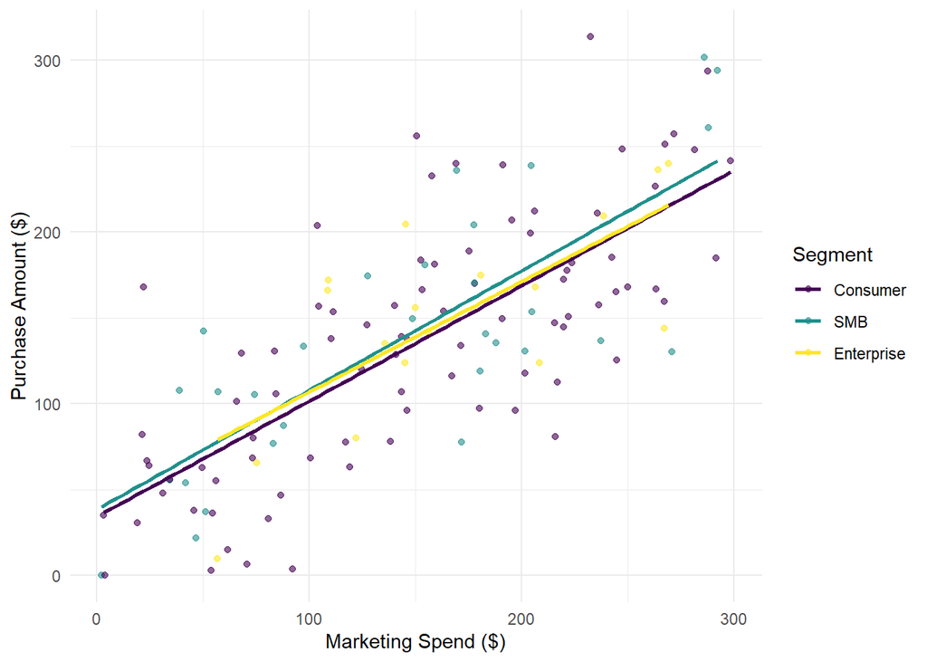

Figure 1: Marketing Spend vs Purchase Amount by Segment

As detailed in Table 1, the average marketing spend and purchase behavior vary across the three segments, with the Enterprise segment showing the highest average marketing spend at $174.73, while the Consumer segment contributed the vast majority of platform traffic with 511 total visits.

Furthermore, Figure 1 illustrates the linear relationship between spending and revenue, a deeper look at the ROI reveals a more complex financial reality. Although the mean ROI is 12.7%, the typical (median) ROI is slightly negative at -7%. This highly skewed distribution suggests that a small number of high-performing accounts offset a larger group of underperforming customers who have yet to reach a break-even threshold.

## Results

The relationship between marketing expenditure and revenue is examined through both aggregate performance metrics (Table 2) and non-linear trend analysis (Figure 2).

As detailed in Table 2, the marketing campaign faces significant efficiency challenges. While the overall mean ROI stands at 12.7%, this figure is heavily skewed. The median ROI is negative (-6.9%), and 60.6% of all customer interactions have a negative ROI. This high prevalence of loss justifies the use of non-linear LOESS smoothing in Figure 2 to identify the specific “efficiency windows” that maximize marginal returns.

Table 2: ROI Summary Statistics by Market Segment

| segment | Customers | Mean ROI (%) | Median ROI (%) | Positive ROI (n) | Negative ROI (n) | % Negative ROI | Mean Spend ($) | Mean Purchase ($) |
| --- | --- | --- | --- | --- | --- | --- | --- | --- |
| Consumer | 85 | 18.3% | -6.3% | 33 | 52 | 61.2% | $151.09 | $135.84 |
| SMB | 30 | 8.4% | 0% | 15 | 15 | 50% | $144.27 | $138.7 |
| Enterprise | 17 | -8.4% | -10.9% | 4 | 13 | 76.5% | $166.96 | $149.94 |
| ALL | 132 | 12.7% | -6.9% | 52 | 80 | 60.6% | $151.58 | $138.31 |

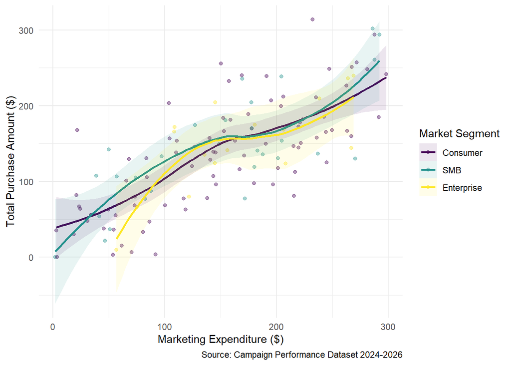

Figure 2: Non-linear smoothing (LOESS) identifying potential points of diminishing marginal returns in marketing spend.

The LOESS analysis in Figure 2 reveals that revenue growth is not proportional to expenditure. Instead, distinct saturation thresholds appear across the three segments:

Table 3: Detailed ROI Analysis by Segment and Spend Bracket

| Segment | Spend Bracket | Avg ROI (%) | Sample Size (n) |
| --- | --- | --- | --- |
| Consumer | Low ($0-100) | 85.0% | 25 |
|  | Mid ($100-200) | 1.8% | 32 |
|  | High ($200+) | -22.3% | 28 |
| SMB | Low ($0-100) | 35.8% | 12 |
|  | Mid ($100-200) | -3.6% | 10 |
|  | High ($200+) | -17.7% | 8 |
| Enterprise | Low ($0-100) | -47.8% | 2 |
|  | Mid ($100-200) | 10.3% | 9 |
|  | High ($200+) | -23.2% | 6 |